# ————————————————————–

# Made by OMELCHUK OLEH, ZINCHUK YURII, HREBENIUK DMYTRO

# ————————————————————–

# Probability and Statistics

# Lab Assignment 1: Naive Bayes Classifier

## Introduction

During the past three weeks, you learned a couple of essential notions and theorems, and one of the most important among them is the *Bayes theorem*.

One of its applications is **Naive Bayes classifier**, which is a probabilistic classifier whose aim is to determine which class some observation probably belongs to by using the Bayes formula:
$$\mathsf{P}(\mathrm{class}\mid
\mathrm{observation})=\frac{\mathsf{P}(\mathrm{observation}\mid\mathrm{class})\mathsf{P}(\mathrm{class})}{\mathsf{P}(\mathrm{observation})}$$

Under the strong independence assumption, one can calculate $\mathsf{P}(\mathrm{observation} \mid \mathrm{class})$ as
$$\mathsf{P}(\mathrm{observation}) =
\prod_{i=1}^{n} \mathsf{P}(\mathrm{feature}_i), \qquad
\mathsf{P}(\mathrm{observation} \mid \mathrm{class}) = \prod_{i=1}^{n}
\mathsf{P}(\mathrm{feature}_i \mid \mathrm{class}),$$
where $n$ is the total number of features describing a given observation. Thus, $\mathsf{P}(\mathrm{class}|\mathrm{observation})$ now can be calculated as

$$\mathsf{P}(\mathrm{class} \mid
\mathrm{\mathrm{observation}}) = \mathsf{P}(\mathrm{class})\times
\prod_{i=1}^{n}\frac{\mathsf{P}(\mathrm{feature}_i\mid
\mathrm{class})}{\mathsf{P}(\mathrm{feature}_i)}\tag{1}$$

All the terms on the right-hand side can be estimated from the data as respective relative frequencies;  
see [this site](https://monkeylearn.com/blog/practical-explanation-naive-bayes-classifier/) for more detailed explanations.

## Data description

There are 5 datasets uploaded on the cms.

To determine your variant, take your team number from the list of teams on cms and take *mod 5* - this is the number of your data set.

- **0 - authors** This data set consists of citations of three famous writers: Edgar Alan Poe, Mary Wollstonecraft Shelley and HP Lovecraft. The task with this data set is to classify a piece of text with the author who was more likely to write it.
- **1 - discrimination** This data set consists of tweets that have discriminatory (sexism or racism) messages or of tweets that are of neutral mood. The task is to determine whether a given tweet has discriminatory mood or does not.
- **2 - fake news** This data set contains data of American news: a headline and an abstract of the article. Each piece of news is classified as fake or credible. The task is to classify the news from test.csv as credible or fake.
- **3 - sentiment** All the text messages contained in this data set are labeled with three sentiments: positive, neutral or negative. The task is to classify some text message as the one of positive mood, negative or neutral.
- **4 - spam** This last data set contains SMS messages classified as spam or non-spam (ham in the data set). The task is to determine whether a given message is spam or non-spam.

Each data set consists of two files: *train.csv* and *test.csv*. The first one you will need find the probabilities distributions for each of the features, while the second one is needed for checking how well your classifier works.

```r
# here goes a list of recommended libraries,
# though you may install other ones if they are needed

# install.packages("tidytext")
# install.packages("dplyr")
# install.packages("readr")
# install.packages("ggplot2")
# install.packages("stringr")
# install.packages("crayon")


library(tidytext)
library(readr)
library(dplyr)
library(ggplot2)
library(stringr)
library(crayon)
```

## Instructions

- The first step is data pre-processing, which includes removing punctuation marks and stop words
- represent each message as a bag-of-words
- using the training set, calculate all the conditional probabilities in formula (1)
- use those to predict classes for messages in the test set
- evaluate effectiveness of the classifier by calculating the corresponding metrics
- shortly summarize your work
- do not forget to submit both the (compiled) Rmd source file and the .html output

### Data pre-processing

- Read the *.csv* data files.
- Сlear your data from punctuation or other unneeded symbols.
- Clear you data from stop words. You don’t want words as is, and, or etc. to affect your probabilities distributions, so it is a wise decision to get rid of them. Find list of stop words in the cms under the lab task.
- Represent each test message as its bag-of-words. Here: https://machinelearningmastery.com/gentle-introduction-bag-words-model/ you can find general introduction to the bag-of-words model and examples on to create it.
- It is highly recommended to get familiar with R dataframes, it would make the work much easier to do.
- Useful links:
  - https://steviep42.github.io/webscraping/book/bagofwords.html#tidytext - example of using *tidytext* to count frequencies of the words.
  - Basics of Text Mining in R: http://rstudio-pubs-static.s3.amazonaws.com/256588_57b585da6c054349825cba46685d8464.html . Note that it also includes an example on how to create a bag of words from your text document.

```r
list.files(getwd())
```

```
## [1] "Data"
## [2] "Lab1.Rproj"
## [3] "Lab1_Naive_Bayes_Classifier_Templatee.html"
## [4] "Lab1_Naive_Bayes_Classifier_Templatee.Rmd"
```

```r
list.files("data/0-authors")
```

```
## character(0)
```

```r
test_path <- "Data/test.csv"
train_path <- "Data/train.csv"

stop_words <- read_file("Data/stop_words.txt")
# https://stackoverflow.com/questions/27195912/why-does-strsplit-return-a-list
splitted_stop_words <- strsplit(stop_words, split='\n')
splitted_stop_words <- splitted_stop_words[[1]]
```

```r
train <-  read.csv(file = train_path, stringsAsFactors = FALSE)
test <-  read.csv(file = test_path, stringsAsFactors = FALSE)
```

```r
# note the power functional features of R bring us!
tidy_text <- unnest_tokens(train, 'splitted', 'text', token="words") %>%
             filter(!splitted %in% splitted_stop_words)
```

### Data visualization

Each time you work with some data, you need to understand it before you start processing it. R has very powerful tools to make nice plots and visualization. Show what are the most common words for negative and positive examples as a histogram, word cloud etc. Be creative!

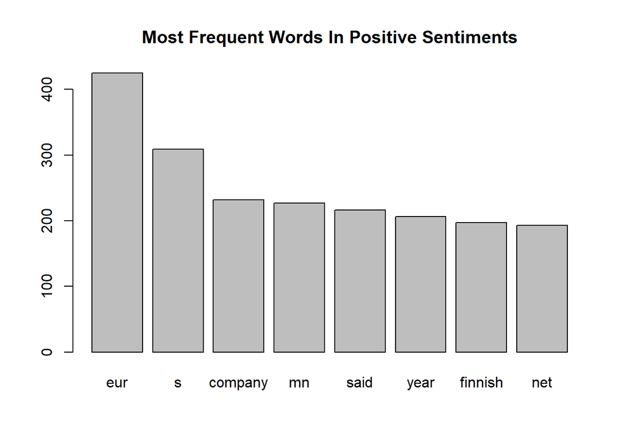

```r
positive_words <- head((tidy_text %>% filter(sentiment == "positive") %>% count(splitted, sort = TRUE)), 8)
neutral_words <- head((tidy_text %>% filter(sentiment == "neutral") %>% count(splitted, sort = TRUE)), 8)
negative_words <- head((tidy_text %>% filter(sentiment == "negative") %>% count(splitted, sort = TRUE)), 8)

barplot(positive_words$n, names.arg=positive_words$splitted, main="Most Frequent Words In Positive Sentiments")
```

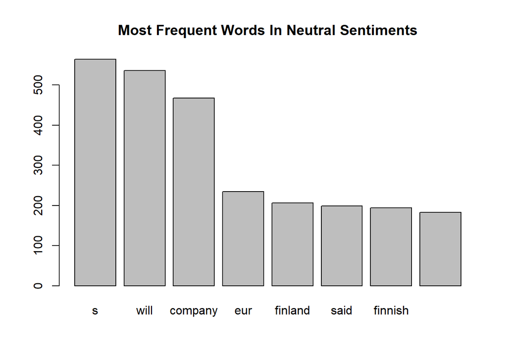

```r
barplot(neutral_words$n, names.arg=neutral_words$splitted, main="Most Frequent Words In Neutral Sentiments")
```

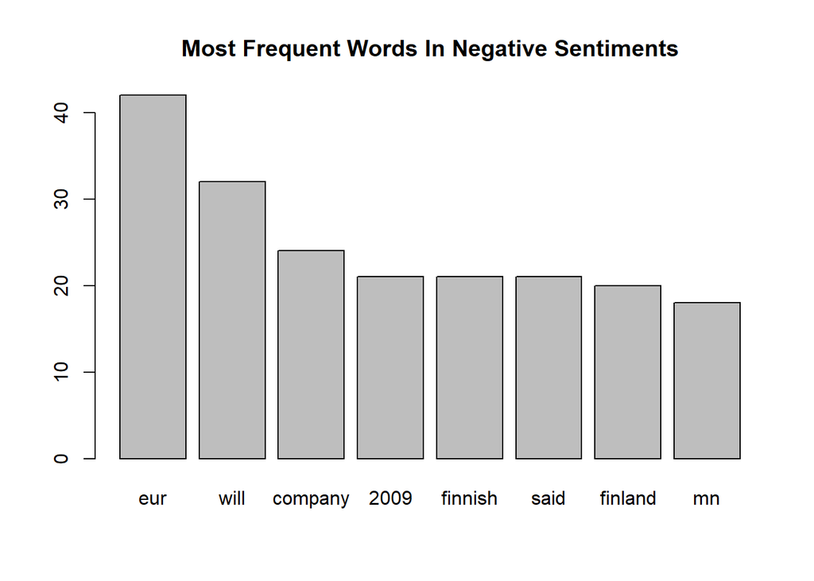

```r
barplot(negative_words$n, names.arg=negative_words$splitted, main="Most Frequent Words In Negative Sentiments")
```

## Classifier implementation

```r
naiveBayes <- setRefClass("naiveBayes",

       # here it would be wise to have some vars to store intermediate result
       # frequency dict etc. Though pay attention to bag of wards!
       fields = list(positive_data="data.frame",negative_data="data.frame",neutral_data="data.frame", prob_positive = "numeric",prob_negative = "numeric",prob_neutral = "numeric",unknown_word_count="numeric",all_word_count="numeric",
       precision_positive="numeric", precision_neutral="numeric", precision_negative="numeric", f1_positive="numeric", f1_neutral="numeric", f1_negative="numeric",
       recall_positive="numeric", recall_neutral="numeric", recall_negative="numeric"),
       methods = list(
      # prepare your training data as X - bag of words for each of your
      # messages and corresponding label for the message encoded as 0 or 1
      # (binary classification task)
      fit = function(data)
      {
           positive_data <<- data %>%
                       filter(sentiment =="positive")%>%
                       count(splitted,sort=TRUE)
           negative_data <<- data %>%
                       filter(sentiment =="negative")%>%
                       count(splitted,sort=TRUE)
           neutral_data <<- data %>%
                       filter(sentiment =="neutral")%>%
                       count(splitted,sort=TRUE)

           unique_count = nrow(data %>% count(splitted))
           positive_data$prob <<- (positive_data$n+1)/(sum(positive_data$n)+unique_count)
           negative_data$prob <<- (negative_data$n+1)/(sum(negative_data$n)+unique_count)
           neutral_data$prob <<- (neutral_data$n+1)/(sum(neutral_data$n)+unique_count)

           prob_positive<<- nrow(train %>% filter(sentiment =="positive")) / nrow(train)
           prob_negative<<- nrow(train %>% filter(sentiment =="negative")) / nrow(train)
           prob_neutral<<- nrow(train %>% filter(sentiment =="neutral")) / nrow(train)
      },

      predict = function(msg)
      {
           msg <- gsub("[`[:punct:]]", '', msg)
           words = str_split(tolower(msg)," ")[[1]]
           words = words[!words %in% splitted_stop_words]

           pos = prob_positive
           neg = prob_negative
           neut = prob_neutral
           for(word in words){
             all_word_count<<-all_word_count+1
             if(!word %in% positive_data$splitted | !word %in% negative_data$splitted | !word %in% neutral_data$splitted)
               unknown_word_count <<- unknown_word_count+1

             if(word %in% positive_data$splitted)
               pos = pos*positive_data$prob[
                  which(positive_data$splitted==word)]
             else
               pos = pos/(nrow(tidy_text)+sum(positive_data$n))

             if(word %in% negative_data$splitted)
               neg = neg*negative_data$prob[
                  which(negative_data$splitted==word)]
             else
               neg = neg/(nrow(tidy_text)+sum(negative_data$n))

             if(word %in% neutral_data$splitted)
               neut = neut*neutral_data$prob[
                  which(neutral_data$splitted==word)]
             else
               neut = neut/(nrow(tidy_text)+sum(neutral_data$n))
           }

           if(max(pos,neg,neut)==pos)
             return("positive")
           else if(max(pos,neg,neut)==neg)
             return("negative")
           else
             return("neutral")

      },

      # score you test set so to get the understanding how well you model
      # works.
      # look at f1 score or precision and recall
      # visualize them
      # try how well your model generalizes to real world data!
      score = function(test)
      {
           unknown_word_count<<-0
           all_word_count<<-0
           test$guess = apply(test["text"], FUN = .self$predict, MARGIN = 1)
           test = test[c("text","sentiment","guess")] #swap rows

           cat("Unknown words:",unknown_word_count,"\n")
           cat("All words:",all_word_count,"\n")

           correctly_guessed = nrow(test %>% filter(test$guess==test$sentiment))
           wrongly_guessed = nrow(test %>% filter(test$guess!=test$sentiment))
           correct_rate = correctly_guessed/(correctly_guessed+wrongly_guessed)

           correctly_guessed_positive = nrow(test %>% filter(test$sentiment=="positive" & test$guess==test$sentiment))
           overall_positive = nrow(test %>% filter(test$sentiment=="positive"))
           recall_positive <<- correctly_guessed_positive/overall_positive

           correctly_guessed_negative = nrow(test %>% filter(test$sentiment=="negative" & test$guess==test$sentiment))
           overall_negative = nrow(test %>% filter(test$sentiment=="negative"))
           recall_negative <<- correctly_guessed_negative/overall_negative

           correctly_guessed_neutral = nrow(test %>% filter(test$sentiment=="neutral" & test$guess==test$sentiment))
           overall_neutral = nrow(test %>% filter(test$sentiment=="neutral"))
           recall_neutral <<- correctly_guessed_neutral/overall_neutral

           cat(green("Recall positive:",recall_positive,"\n"))
           cat(red("Recall negative:",recall_neutral,"\n"))
           cat(yellow("Recall neutral:",recall_negative,"\n\n"))

           guessed_positive = nrow(test %>% filter(test$guess=="positive"))
           precision_positive <<- correctly_guessed_positive/guessed_positive

           guessed_negative = nrow(test %>% filter(test$guess=="negative"))
           precision_negative <<- correctly_guessed_negative/guessed_negative

           guessed_neutral = nrow(test %>% filter(test$guess=="neutral"))
           precision_neutral <<- correctly_guessed_neutral/guessed_neutral

           cat(green("Guessed positive:",guessed_positive,"\n"))
           cat(red("Guessed negative:",guessed_negative,"\n"))
           cat(yellow("Guessed neutral:",guessed_neutral,"\n\n"))

           cat(green("Precision positive:",precision_positive,"\n"))
           cat(red("Precision negative:",precision_negative,"\n"))
           cat(yellow("Precision neutral:",precision_neutral,"\n\n"))

           f1_positive <<- 2*precision_positive*recall_positive/(precision_positive+recall_positive)
           f1_negative <<- 2*precision_negative*recall_negative/(precision_negative+recall_negative)
           f1_neutral <<- 2*precision_neutral*recall_neutral/(precision_neutral+recall_neutral)

           cat(green("F1 positive:",f1_positive,"\n"))
           cat(red("F1 negative:",f1_negative,"\n"))
           cat(yellow("F1 neutral:",f1_neutral,"\n\n"))
      }
))


model = naiveBayes()
model$fit(tidy_text)
model$score(test)
```

[output not shown]

## Measure effectiveness of your classifier

- Note that accuracy is not always a good metric for your classifier. Look at precision and recall curves, F1 score metric.
- Visualize them.
- Show failure cases.

```r
sentiment <- c("positive", "neutral", "negative")
model$precision_negative
```

```
## [1] 0.5
```

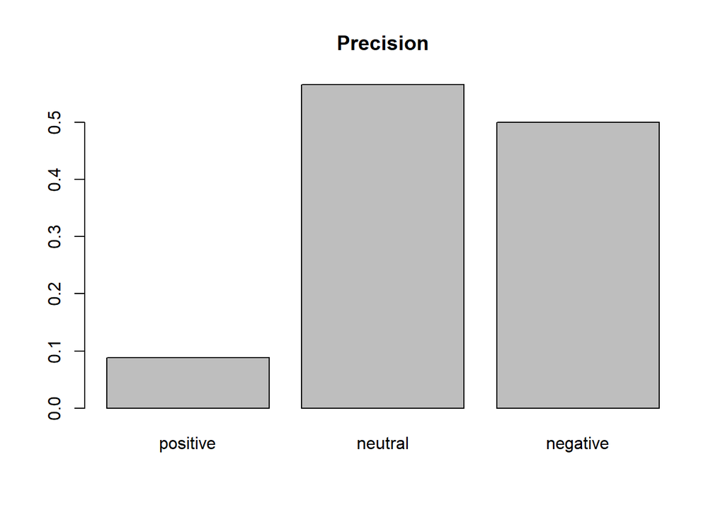

```r
precision <- c(model$precision_positive, model$precision_neutral, model$precision_negative)
recall <- c(model$recall_positive, model$recall_neutral, model$recall_negative)
f1 <- c(model$f1_positive, model$f1_neutral, model$f1_negative)

metrics <- data.frame(sentiment, precision, recall, f1)

barplot(metrics$precision, names.arg=metrics$sentiment, main="Precision")
```

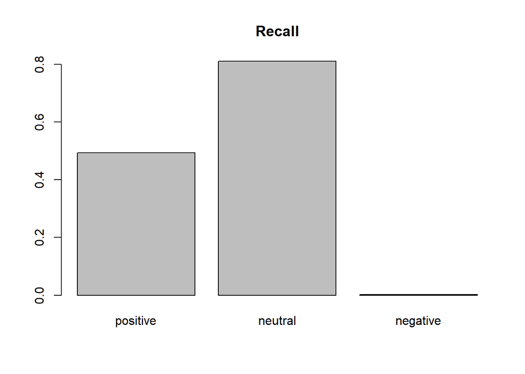

```r
barplot(metrics$recall, names.arg=metrics$sentiment, main="Recall")
```

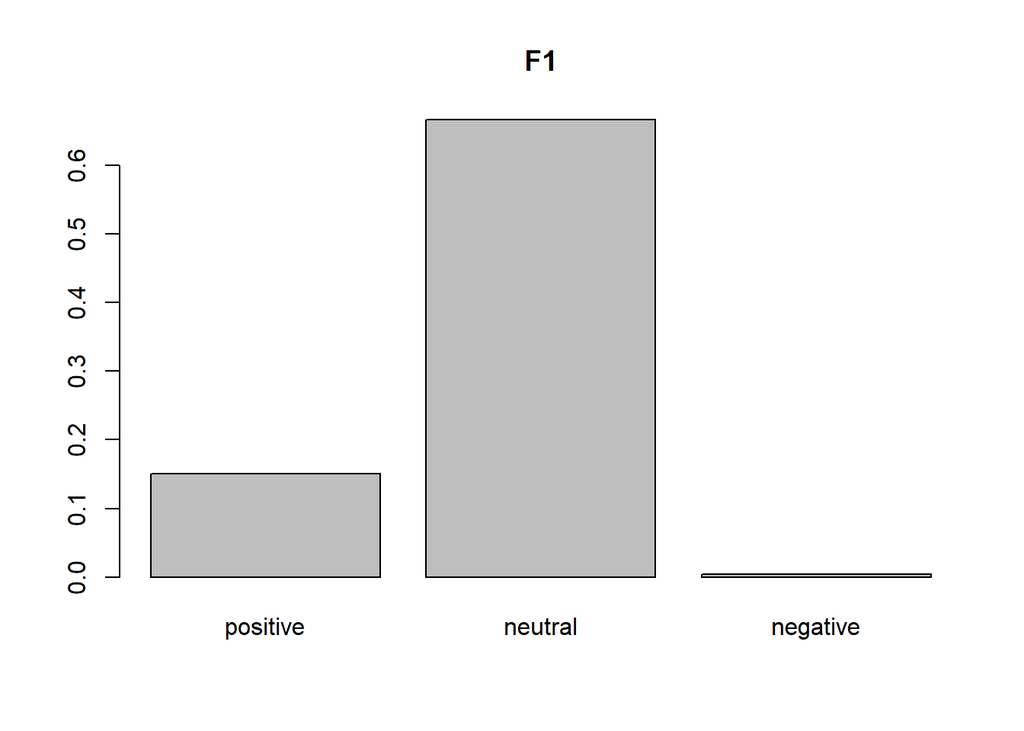

```r
barplot(metrics$f1, names.arg=metrics$sentiment, main="F1")
```

## Conclusions

Summarize your work by explaining in a few sentences the points listed below.

- Describe the method implemented in general. Show what are mathematical foundations you are basing your solution on.
- List pros and cons of the method. This should include the limitations of your method, all the assumption you make about the nature of your data etc.

We implemented Naive Bayes Classifier to predict the sentiment of a message. To do that we used Bayes formula from our PS course. To be more specific, we conditioned the sentiment of the message on the words in it. To do that we took our training data set, counted how many times each word from it occured in each sentiment. Then we created three data frames (one for each sentiment): each containing words that occurred in messages of corresponding sentiment, their frequency and their relative probability to appear in this sentiment. We also calculated probability of message of each sentiment to occur. This was the “training” of our model.

After that we predicted sentiment of a given message by calculating it’s probability to occur in each sentiment’s message and choosing the biggest. This was done by multiplying each word’s from the message probability to occur in the particular sentiment’s message for each sentiment separately. This gave us probability of the message to occur in the sentiment. Then we had to multiply it by probability of occurance of corresponding sentiment. Then we chose the biggest probability and returned corresponding sentiment.

Pros and Cons:

Pros of this method are: It is fairly easy to implement and therefore is good for learning purposes. It is also good at showing how to apply theoretical knowledge to solve real-life problems.

Cons of this method are: It isn’t accurate for predicting data when it is disbalances and especially when there are more than to classes to predict. Also, it doesn’t take into account the grammar structures, words bindings and effect that words have on each other in the sentence. Hence, it only looks on the words itself, ignoring the greater meaning. This results in poor quality of the model. Well, at least in our case. It also handles poorly the situation when the dataset is imbalanced in a different way in training and testing datasets. For example, in our training dataset, the ratio of negative messages to all messages was extremely low, whereas in the testing set it was bigger. This caused problems when predicting for negative cases, as you can see on metrics’ bar charts. Also, we noticed a big confusion between positive and neutral messages, because the line between them is not that clear and our model cannot handle that very well.